# linear regression

```r
library(readxl)
library(readr)
library(car)
library(MASS)
```

# 1. simple linear regression

```r
data1 <- read_excel("C:/Users/wjssm/Desktop/lr/data1.XLS")
data1
```

```
## # A tibble: 20 x 2
##        y     x
##    <dbl> <dbl>
##  1  86.9  1.02
##  2  89.8  1.11
##  3  90.3  1.43
##  4  86.3  1.11
##  5  92.6  1.01
##  6  87.3  0.95
##  7  86.3  1.11
##  8  91.9  0.87
##  9  95.6  1.43
## 10  89.9  1.02
## 11  96.7  1.46
## 12  99.4  1.55
## 13  98.7  1.55
## 14  96.1  1.55
## 15  93.6  1.4
## 16  87.3  1.15
## 17  95    1.01
## 18  96.8  0.99
## 19  85.2  0.95
## 20  90.6  0.98
```

```r
lr1 <- lm(y ~ x , data = data1)
lr1
```

```
##
## Call:
## lm(formula = y ~ x, data = data1)
##
## Coefficients:
## (Intercept)            x
##       77.86        11.80
```

```r
summary(lr1)
```

```
##
## Call:
## lm(formula = y ~ x, data = data1)
##
## Residuals:
##     Min      1Q  Median      3Q     Max
## -4.6724 -3.2113 -0.0626  2.5783  7.3037
##
## Coefficients:
##             Estimate Std. Error t value Pr(>|t|)
## (Intercept)   77.863      4.199  18.544 3.54e-13 ***
## x             11.801      3.485   3.386  0.00329 **
## ---
## Signif. codes:  0 '***' 0.001 '**' 0.01 '*' 0.05 '.' 0.1 ' ' 1
##
## Residual standard error: 3.597 on 18 degrees of freedom
## Multiple R-squared:  0.3891, Adjusted R-squared:  0.3552
## F-statistic: 11.47 on 1 and 18 DF,  p-value: 0.003291
```

### residual(잔차)

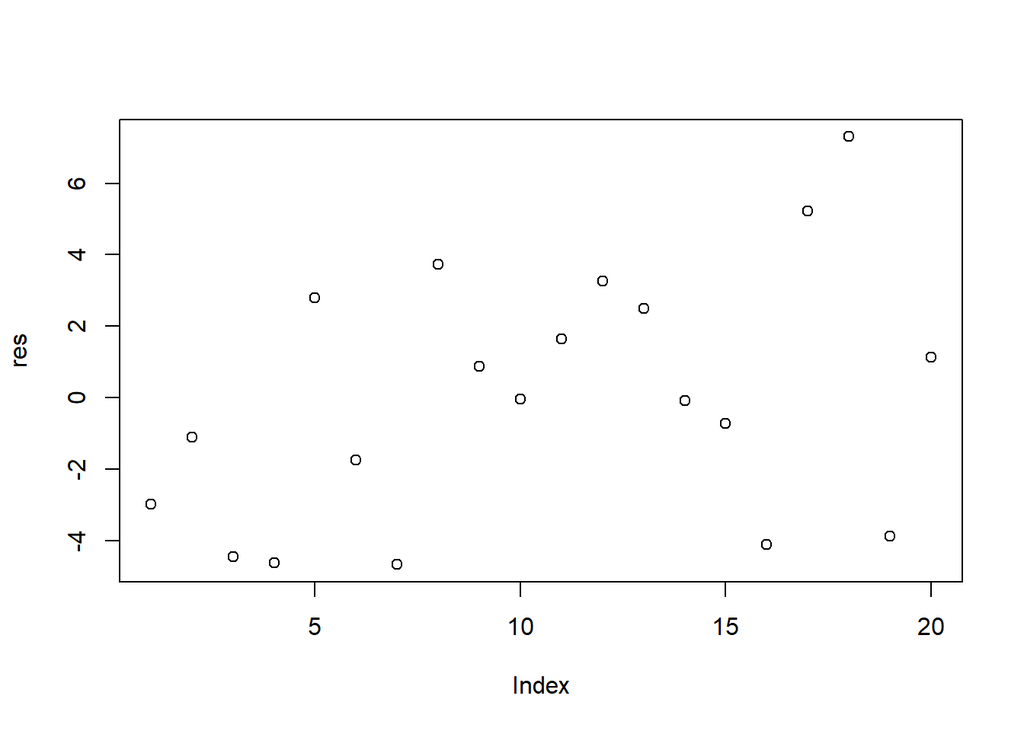

```r
res<-resid(lr1) # data1$y-predict(lr1, data1)
plot(res)
```

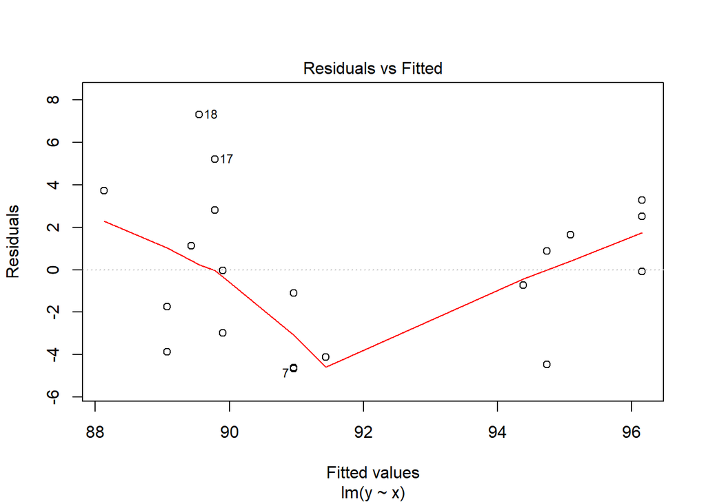

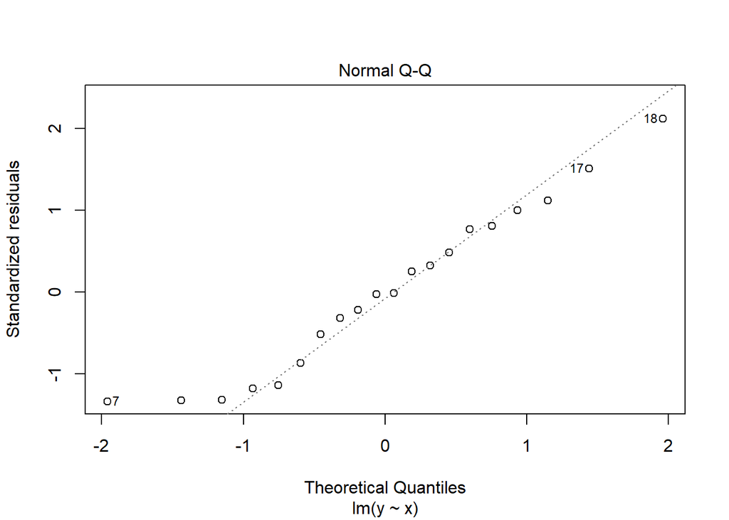

```r
plot(lr1, which=1:2)
```

- graph 설명
- 1 잔차 vs 순서 그림 : 독립성 가정 확인
- 2-잔차 vs 적합치 : 등분산성 가정 확인
- 3-잔차의 Q-Q plot : 정규성 가정 확인

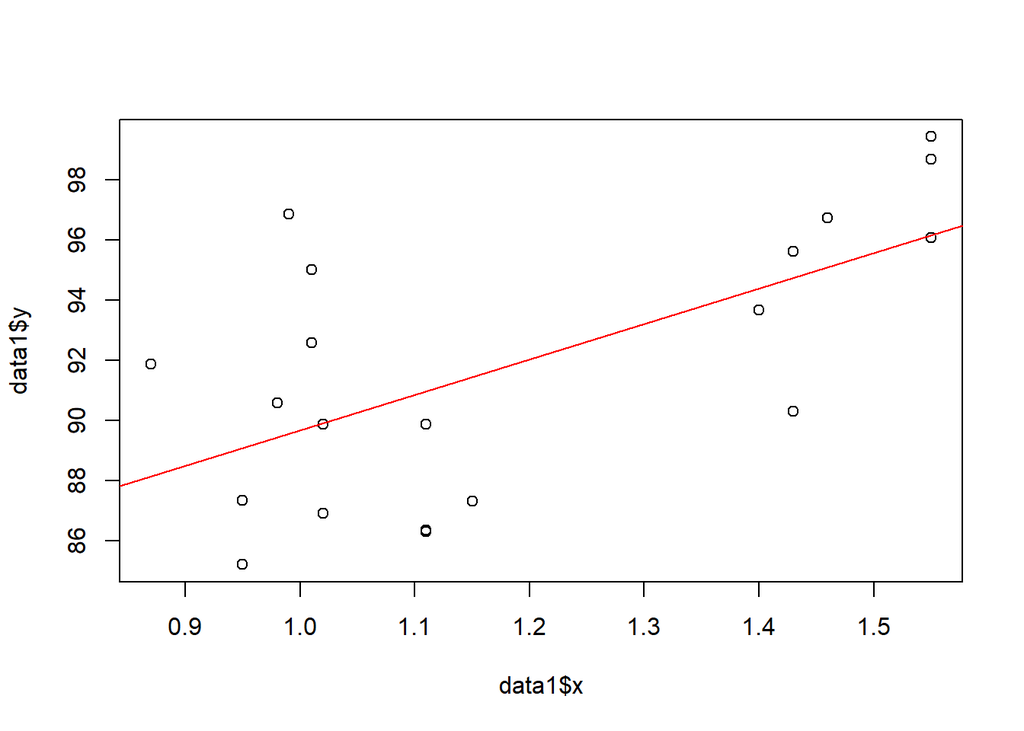

```r
plot(data1$x,data1$y)
abline(lr1$coefficients[1], lr1$coefficients[2],col="red")
```

```r
summary(lr1)
```

```
##
## Call:
## lm(formula = y ~ x, data = data1)
##
## Residuals:
##     Min      1Q  Median      3Q     Max
## -4.6724 -3.2113 -0.0626  2.5783  7.3037
##
## Coefficients:
##             Estimate Std. Error t value Pr(>|t|)
## (Intercept)   77.863      4.199  18.544 3.54e-13 ***
## x             11.801      3.485   3.386  0.00329 **
## ---
## Signif. codes:  0 '***' 0.001 '**' 0.01 '*' 0.05 '.' 0.1 ' ' 1
##
## Residual standard error: 3.597 on 18 degrees of freedom
## Multiple R-squared:  0.3891, Adjusted R-squared:  0.3552
## F-statistic: 11.47 on 1 and 18 DF,  p-value: 0.003291
```

```r
summary(lr1)$r.squared
```

```
## [1] 0.3891224
```

# 2.multiple linear regression

```r
data(Boston);str(Boston)
```

```
## 'data.frame':    506 obs. of  14 variables:
##  $ crim   : num  0.00632 0.02731 0.02729 0.03237 0.06905 ...
##  $ zn     : num  18 0 0 0 0 0 12.5 12.5 12.5 12.5 ...
##  $ indus  : num  2.31 7.07 7.07 2.18 2.18 2.18 7.87 7.87 7.87 7.87 ...
##  $ chas   : int  0 0 0 0 0 0 0 0 0 0 ...
##  $ nox    : num  0.538 0.469 0.469 0.458 0.458 0.458 0.524 0.524 0.524 0.524 ...
##  $ rm     : num  6.58 6.42 7.18 7 7.15 ...
##  $ age    : num  65.2 78.9 61.1 45.8 54.2 58.7 66.6 96.1 100 85.9 ...
##  $ dis    : num  4.09 4.97 4.97 6.06 6.06 ...
##  $ rad    : int  1 2 2 3 3 3 5 5 5 5 ...
##  $ tax    : num  296 242 242 222 222 222 311 311 311 311 ...
##  $ ptratio: num  15.3 17.8 17.8 18.7 18.7 18.7 15.2 15.2 15.2 15.2 ...
##  $ black  : num  397 397 393 395 397 ...
##  $ lstat  : num  4.98 9.14 4.03 2.94 5.33 ...
##  $ medv   : num  24 21.6 34.7 33.4 36.2 28.7 22.9 27.1 16.5 18.9 ...
```

```r
lr2<-lm(medv~., data = Boston) #lm(y~x1+x2) or lm(y~.-x1-x2)
summary(lr2)
```

```
##
## Call:
## lm(formula = medv ~ ., data = Boston)
##
## Residuals:
##     Min      1Q  Median      3Q     Max
## -15.595  -2.730  -0.518   1.777  26.199
##
## Coefficients:
##               Estimate Std. Error t value Pr(>|t|)
## (Intercept)  3.646e+01  5.103e+00   7.144 3.28e-12 ***
## crim        -1.080e-01  3.286e-02  -3.287 0.001087 **
## zn           4.642e-02  1.373e-02   3.382 0.000778 ***
## indus        2.056e-02  6.150e-02   0.334 0.738288
## chas         2.687e+00  8.616e-01   3.118 0.001925 **
## nox         -1.777e+01  3.820e+00  -4.651 4.25e-06 ***
## rm           3.810e+00  4.179e-01   9.116  < 2e-16 ***
## age          6.922e-04  1.321e-02   0.052 0.958229
## dis         -1.476e+00  1.995e-01  -7.398 6.01e-13 ***
## rad          3.060e-01  6.635e-02   4.613 5.07e-06 ***
## tax         -1.233e-02  3.760e-03  -3.280 0.001112 **
## ptratio     -9.527e-01  1.308e-01  -7.283 1.31e-12 ***
## black        9.312e-03  2.686e-03   3.467 0.000573 ***
## lstat       -5.248e-01  5.072e-02 -10.347  < 2e-16 ***
## ---
## Signif. codes:  0 '***' 0.001 '**' 0.01 '*' 0.05 '.' 0.1 ' ' 1
##
## Residual standard error: 4.745 on 492 degrees of freedom
## Multiple R-squared:  0.7406, Adjusted R-squared:  0.7338
## F-statistic: 108.1 on 13 and 492 DF,  p-value: < 2.2e-16
```

### residual(잔차)

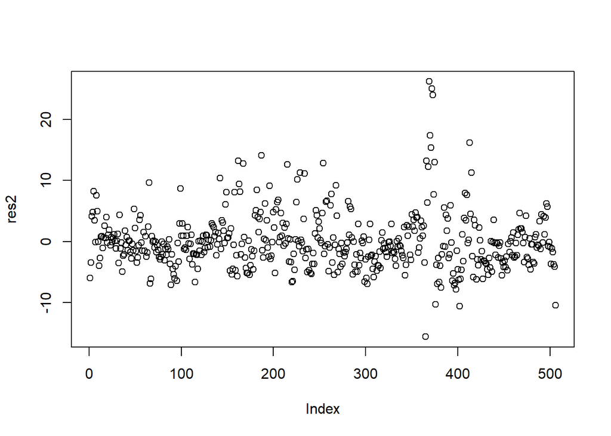

```r
res2<-resid(lr2)
plot(res2)
```

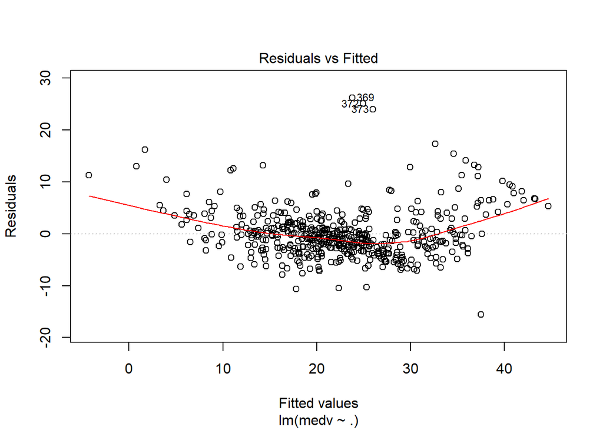

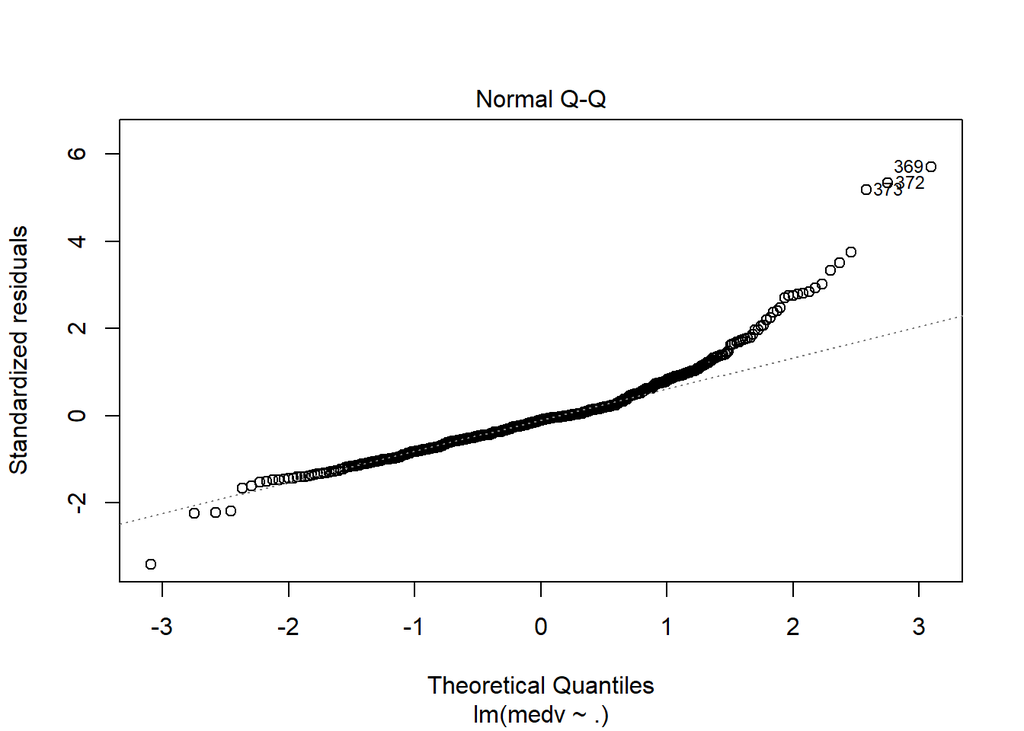

```r
plot(lr2, which=1:2)
```

잔차의 독립성, 정규성, 등분산성 확인

### multicolinearity(다중공선성)

##### correlation

```r
cor(Boston[,-14])
```

```
##                crim          zn       indus         chas         nox
## crim     1.00000000 -0.20046922  0.40658341 -0.055891582  0.42097171
## zn      -0.20046922  1.00000000 -0.53382819 -0.042696719 -0.51660371
## indus    0.40658341 -0.53382819  1.00000000  0.062938027  0.76365145
## chas    -0.05589158 -0.04269672  0.06293803  1.000000000  0.09120281
## nox      0.42097171 -0.51660371  0.76365145  0.091202807  1.00000000
## rm      -0.21924670  0.31199059 -0.39167585  0.091251225 -0.30218819
## age      0.35273425 -0.56953734  0.64477851  0.086517774  0.73147010
## dis     -0.37967009  0.66440822 -0.70802699 -0.099175780 -0.76923011
## rad      0.62550515 -0.31194783  0.59512927 -0.007368241  0.61144056
## tax      0.58276431 -0.31456332  0.72076018 -0.035586518  0.66802320
## ptratio  0.28994558 -0.39167855  0.38324756 -0.121515174  0.18893268
## black   -0.38506394  0.17552032 -0.35697654  0.048788485 -0.38005064
## lstat    0.45562148 -0.41299457  0.60379972 -0.053929298  0.59087892
##                  rm         age         dis          rad         tax
## crim    -0.21924670  0.35273425 -0.37967009  0.625505145  0.58276431
## zn       0.31199059 -0.56953734  0.66440822 -0.311947826 -0.31456332
## indus   -0.39167585  0.64477851 -0.70802699  0.595129275  0.72076018
## chas     0.09125123  0.08651777 -0.09917578 -0.007368241 -0.03558652
## nox     -0.30218819  0.73147010 -0.76923011  0.611440563  0.66802320
## rm       1.00000000 -0.24026493  0.20524621 -0.209846668 -0.29204783
## age     -0.24026493  1.00000000 -0.74788054  0.456022452  0.50645559
## dis      0.20524621 -0.74788054  1.00000000 -0.494587930 -0.53443158
## rad     -0.20984667  0.45602245 -0.49458793  1.000000000  0.91022819
## tax     -0.29204783  0.50645559 -0.53443158  0.910228189  1.00000000
## ptratio -0.35550149  0.26151501 -0.23247054  0.464741179  0.46085304
## black    0.12806864 -0.27353398  0.29151167 -0.444412816 -0.44180801
## lstat   -0.61380827  0.60233853 -0.49699583  0.488676335  0.54399341
##            ptratio       black      lstat
## crim     0.2899456 -0.38506394  0.4556215
## zn      -0.3916785  0.17552032 -0.4129946
## indus    0.3832476 -0.35697654  0.6037997
## chas    -0.1215152  0.04878848 -0.0539293
## nox      0.1889327 -0.38005064  0.5908789
## rm      -0.3555015  0.12806864 -0.6138083
## age      0.2615150 -0.27353398  0.6023385
## dis     -0.2324705  0.29151167 -0.4969958
## rad      0.4647412 -0.44441282  0.4886763
## tax      0.4608530 -0.44180801  0.5439934
## ptratio  1.0000000 -0.17738330  0.3740443
## black   -0.1773833  1.00000000 -0.3660869
## lstat    0.3740443 -0.36608690  1.0000000
```

```r
symnum(abs(round(cor(Boston[,-14]),2)))
```

```
##         cr z i ch n rm a d rd t p b l
## crim    1
## zn         1
## indus   .  . 1
## chas           1
## nox     .  . ,    1
## rm         . .      1
## age     .  . ,    ,    1
## dis     .  , ,    ,    , 1
## rad     ,  . .    ,    . . 1
## tax     .  . ,    ,    . . *  1
## ptratio    . .      .      .  . 1
## black   .    .    .        .  .   1
## lstat   .  . .    . ,  . . .  . . . 1
## attr(,"legend")
## [1] 0 ' ' 0.3 '.' 0.6 ',' 0.8 '+' 0.9 '*' 0.95 'B' 1
```

tax, rad변수 상관관계 매우 높음.

##### vif : 보통 vif>5 주의, vif > 10 다중공선성이 있다고 판단.

```r
vif(lr2)
```

```
##     crim       zn    indus     chas      nox       rm      age      dis
## 1.792192 2.298758 3.991596 1.073995 4.393720 1.933744 3.100826 3.955945
##      rad      tax  ptratio    black    lstat
## 7.484496 9.008554 1.799084 1.348521 2.941491
```

vif 값 역시 tax, rad변수 값이 매우 큼.

- variable
- tax : full-value property-tax rate per $10,000.
- index of accessibility to radial highways.

```r
lr22<-lm(medv ~. -tax, data=Boston)
summary(lr2)$r.squared; summary(lr22)$r.squared
```

```
## [1] 0.7406427
```

```
## [1] 0.7349714
```

tax 변수가 빠져도 R^2 값은 별 차이 없음. R^2값이 절대적인 모형선택의 기준이라고 할 수 없음. 이럴 경우엔 더 simple한 모형이 좋음.

### variable selection

- step : AIC를 기준으로 좋은 모형을 찾아줌.

```r
#1.backward elimination (default)
###한 번 빠진 변수는 다시 추가될 수 없음.
step(lr2)
```

```
## Start:  AIC=1589.64
## medv ~ crim + zn + indus + chas + nox + rm + age + dis + rad +
##     tax + ptratio + black + lstat
##
##           Df Sum of Sq   RSS    AIC
## - age      1      0.06 11079 1587.7
## - indus    1      2.52 11081 1587.8
## <none>                 11079 1589.6
## - chas     1    218.97 11298 1597.5
## - tax      1    242.26 11321 1598.6
## - crim     1    243.22 11322 1598.6
## - zn       1    257.49 11336 1599.3
## - black    1    270.63 11349 1599.8
## - rad      1    479.15 11558 1609.1
## - nox      1    487.16 11566 1609.4
## - ptratio  1   1194.23 12273 1639.4
## - dis      1   1232.41 12311 1641.0
## - rm       1   1871.32 12950 1666.6
## - lstat    1   2410.84 13490 1687.3
##
## Step:  AIC=1587.65
## medv ~ crim + zn + indus + chas + nox + rm + dis + rad + tax +
##     ptratio + black + lstat
##
##           Df Sum of Sq   RSS    AIC
## - indus    1      2.52 11081 1585.8
## <none>                 11079 1587.7
## - chas     1    219.91 11299 1595.6
## - tax      1    242.24 11321 1596.6
## - crim     1    243.20 11322 1596.6
## - zn       1    260.32 11339 1597.4
## - black    1    272.26 11351 1597.9
## - rad      1    481.09 11560 1607.2
## - nox      1    520.87 11600 1608.9
## - ptratio  1   1200.23 12279 1637.7
## - dis      1   1352.26 12431 1643.9
## - rm       1   1959.55 13038 1668.0
## - lstat    1   2718.88 13798 1696.7
##
## Step:  AIC=1585.76
## medv ~ crim + zn + chas + nox + rm + dis + rad + tax + ptratio +
##     black + lstat
##
##           Df Sum of Sq   RSS    AIC
## <none>                 11081 1585.8
## - chas     1    227.21 11309 1594.0
## - crim     1    245.37 11327 1594.8
## - zn       1    257.82 11339 1595.4
## - black    1    270.82 11352 1596.0
## - tax      1    273.62 11355 1596.1
## - rad      1    500.92 11582 1606.1
## - nox      1    541.91 11623 1607.9
## - ptratio  1   1206.45 12288 1636.0
## - dis      1   1448.94 12530 1645.9
## - rm       1   1963.66 13045 1666.3
## - lstat    1   2723.48 13805 1695.0
```

```
##
## Call:
## lm(formula = medv ~ crim + zn + chas + nox + rm + dis + rad +
##     tax + ptratio + black + lstat, data = Boston)
##
## Coefficients:
## (Intercept)         crim           zn         chas          nox
##   36.341145    -0.108413     0.045845     2.718716   -17.376023
##          rm          dis          rad          tax      ptratio
##    3.801579    -1.492711     0.299608    -0.011778    -0.946525
##       black        lstat
##    0.009291    -0.522553
```

```r
#2.forward selection
###한 번 추가된 변수는 다시 빠질 수 없음.
lr2m<-lm(medv ~ 1, data=Boston)
step(lr2m, direction="forward", scope=formula(lr2))
```

```
## Start:  AIC=2246.51
## medv ~ 1
##
##           Df Sum of Sq   RSS    AIC
## + lstat    1   23243.9 19472 1851.0
## + rm       1   20654.4 22062 1914.2
## + ptratio  1   11014.3 31702 2097.6
## + indus    1    9995.2 32721 2113.6
## + tax      1    9377.3 33339 2123.1
## + nox      1    7800.1 34916 2146.5
## + crim     1    6440.8 36276 2165.8
## + rad      1    6221.1 36495 2168.9
## + age      1    6069.8 36647 2171.0
## + zn       1    5549.7 37167 2178.1
## + black    1    4749.9 37966 2188.9
## + dis      1    2668.2 40048 2215.9
## + chas     1    1312.1 41404 2232.7
## <none>                 42716 2246.5
##
## Step:  AIC=1851.01
## medv ~ lstat
##
##           Df Sum of Sq   RSS    AIC
## + rm       1    4033.1 15439 1735.6
## + ptratio  1    2670.1 16802 1778.4
## + chas     1     786.3 18686 1832.2
## + dis      1     772.4 18700 1832.5
## + age      1     304.3 19168 1845.0
## + tax      1     274.4 19198 1845.8
## + black    1     198.3 19274 1847.8
## + zn       1     160.3 19312 1848.8
## + crim     1     146.9 19325 1849.2
## + indus    1      98.7 19374 1850.4
## <none>                 19472 1851.0
## + rad      1      25.1 19447 1852.4
## + nox      1       4.8 19468 1852.9
##
## Step:  AIC=1735.58
## medv ~ lstat + rm
##
```

[output cut: 109 more lines]

```
##
##         Df Sum of Sq   RSS    AIC
## + tax    1   273.619 11081 1585.8
## <none>               11355 1596.1
## + indus  1    33.894 11321 1596.6
## + age    1     0.096 11355 1598.1
##
## Step:  AIC=1585.76
## medv ~ lstat + rm + ptratio + dis + nox + chas + black + zn +
##     crim + rad + tax
##
##         Df Sum of Sq   RSS    AIC
## <none>               11081 1585.8
## + indus  1   2.51754 11079 1587.7
## + age    1   0.06271 11081 1587.8
```

```
##
## Call:
## lm(formula = medv ~ lstat + rm + ptratio + dis + nox + chas +
##     black + zn + crim + rad + tax, data = Boston)
##
## Coefficients:
## (Intercept)        lstat           rm      ptratio          dis
##   36.341145    -0.522553     3.801579    -0.946525    -1.492711
##         nox         chas        black           zn         crim
##  -17.376023     2.718716     0.009291     0.045845    -0.108413
##         rad          tax
##    0.299608    -0.011778
```

```r
#3.both
step(lr2, direction='both')
```

```
## Start:  AIC=1589.64
## medv ~ crim + zn + indus + chas + nox + rm + age + dis + rad +
##     tax + ptratio + black + lstat
##
##           Df Sum of Sq   RSS    AIC
## - age      1      0.06 11079 1587.7
## - indus    1      2.52 11081 1587.8
## <none>                 11079 1589.6
## - chas     1    218.97 11298 1597.5
## - tax      1    242.26 11321 1598.6
## - crim     1    243.22 11322 1598.6
## - zn       1    257.49 11336 1599.3
## - black    1    270.63 11349 1599.8
## - rad      1    479.15 11558 1609.1
## - nox      1    487.16 11566 1609.4
## - ptratio  1   1194.23 12273 1639.4
## - dis      1   1232.41 12311 1641.0
## - rm       1   1871.32 12950 1666.6
## - lstat    1   2410.84 13490 1687.3
##
## Step:  AIC=1587.65
## medv ~ crim + zn + indus + chas + nox + rm + dis + rad + tax +
##     ptratio + black + lstat
##
##           Df Sum of Sq   RSS    AIC
## - indus    1      2.52 11081 1585.8
## <none>                 11079 1587.7
## + age      1      0.06 11079 1589.6
## - chas     1    219.91 11299 1595.6
## - tax      1    242.24 11321 1596.6
## - crim     1    243.20 11322 1596.6
## - zn       1    260.32 11339 1597.4
## - black    1    272.26 11351 1597.9
## - rad      1    481.09 11560 1607.2
## - nox      1    520.87 11600 1608.9
## - ptratio  1   1200.23 12279 1637.7
## - dis      1   1352.26 12431 1643.9
## - rm       1   1959.55 13038 1668.0
## - lstat    1   2718.88 13798 1696.7
##
## Step:  AIC=1585.76
## medv ~ crim + zn + chas + nox + rm + dis + rad + tax + ptratio +
##     black + lstat
##
##           Df Sum of Sq   RSS    AIC
## <none>                 11081 1585.8
## + indus    1      2.52 11079 1587.7
## + age      1      0.06 11081 1587.8
## - chas     1    227.21 11309 1594.0
## - crim     1    245.37 11327 1594.8
## - zn       1    257.82 11339 1595.4
## - black    1    270.82 11352 1596.0
## - tax      1    273.62 11355 1596.1
## - rad      1    500.92 11582 1606.1
## - nox      1    541.91 11623 1607.9
## - ptratio  1   1206.45 12288 1636.0
## - dis      1   1448.94 12530 1645.9
## - rm       1   1963.66 13045 1666.3
## - lstat    1   2723.48 13805 1695.0
```

```
##
## Call:
## lm(formula = medv ~ crim + zn + chas + nox + rm + dis + rad +
##     tax + ptratio + black + lstat, data = Boston)
##
## Coefficients:
## (Intercept)         crim           zn         chas          nox
##   36.341145    -0.108413     0.045845     2.718716   -17.376023
##          rm          dis          rad          tax      ptratio
##    3.801579    -1.492711     0.299608    -0.011778    -0.946525
##       black        lstat
##    0.009291    -0.522553
```

# 3.dummy variable

```r
apt <- read_delim("C:/Users/wjssm/Desktop/lr/apt.txt","\t", escape_double = FALSE,
                  trim_ws = TRUE)
apt
```

```
## # A tibble: 236 x 6
##        y company subway  year  size volume
##    <int> <chr>    <int> <int> <int>  <int>
##  1 31000 GN           0  1984    32    678
##  2 26000 HD           1  1984    31    416
##  3 47500 HD           1  1984    46    416
##  4 59000 HD           1  1984    58    416
##  5 31000 HD           1  1985    32    558
##  6 56000 HD           1  1985    48    558
##  7 56000 HD           1  1985    49    558
##  8 65000 HD           1  1985    59    558
##  9 25500 WS           1  1985    34    405
## 10 49000 WS           1  1985    47    405
## # ... with 226 more rows
```

```r
table(apt$subway) #아파트 근처의 지하철 개수
```

```
##
##   0   1   2
##  53 170  13
```

```r
lm(y~.,data = apt)
```

```
##
## Call:
## lm(formula = y ~ ., data = apt)
##
## Coefficients:
## (Intercept)    companyCG   companyCPC    companyCW    companyDB
##  -2.185e+05    1.295e+03    7.220e+03    5.921e+03    4.807e+03
##   companyDH    companyDI    companyDL    companyDS    companyDW
##   7.150e+02    1.279e+04    1.348e+03    6.737e+03    1.205e+04
##   companyGJ    companyGN    companyGY    companyHB    companyHD
##   1.482e+04    4.749e+03    1.637e+04    9.339e+03    9.212e+03
##   companyHL   companyHPC    companyHS    companyHY    companyJH
##   1.059e+03    4.806e+03    8.008e+03    5.841e+03    1.121e+04
##   companyJY    companyLu   companySDA   companySDY    companySH
##   1.925e+03    2.728e+03    7.557e+03    6.352e+03    8.209e+03
##   companySI    companySK    companySS    companySY    companyWS
##  -2.545e+02    1.350e+04    5.870e+03    6.882e+03    1.118e+04
##      subway         year         size       volume
##   8.495e+02    9.494e+01    1.526e+03    2.126e+00
```

```r
####package 사용 library(dummies) 사용해도 됨.


###as.numeric
apt$bigcompany <- as.numeric(apt$company=='HD' | apt$company=='SS')

apt
```

```
## # A tibble: 236 x 7
##        y company subway  year  size volume bigcompany
##    <int> <chr>    <int> <int> <int>  <int>      <dbl>
##  1 31000 GN           0  1984    32    678          0
##  2 26000 HD           1  1984    31    416          1
##  3 47500 HD           1  1984    46    416          1
##  4 59000 HD           1  1984    58    416          1
##  5 31000 HD           1  1985    32    558          1
##  6 56000 HD           1  1985    48    558          1
##  7 56000 HD           1  1985    49    558          1
##  8 65000 HD           1  1985    59    558          1
##  9 25500 WS           1  1985    34    405          0
## 10 49000 WS           1  1985    47    405          0
## # ... with 226 more rows
```

# 4.variable transforamtion

- 변수 변환은 로그변환, 역수 등 여러가지
- 다양한 상황에서 변환할 수 있음.등 (잔차의 가정을 만족시키지 못한 경우, 선형관계가 잘 보이지 않을 경우 등)

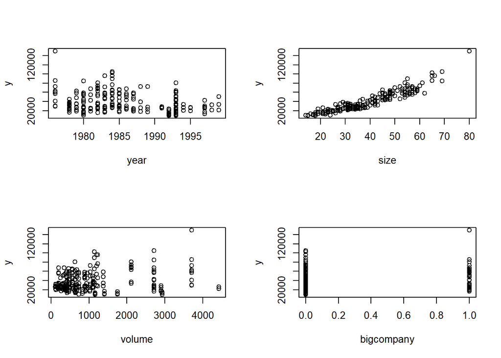

```r
attach(apt)

par(mfrow=c(2,2))
plot(year, y)
plot(size, y)
plot(volume, y)
plot(bigcompany, y)
```

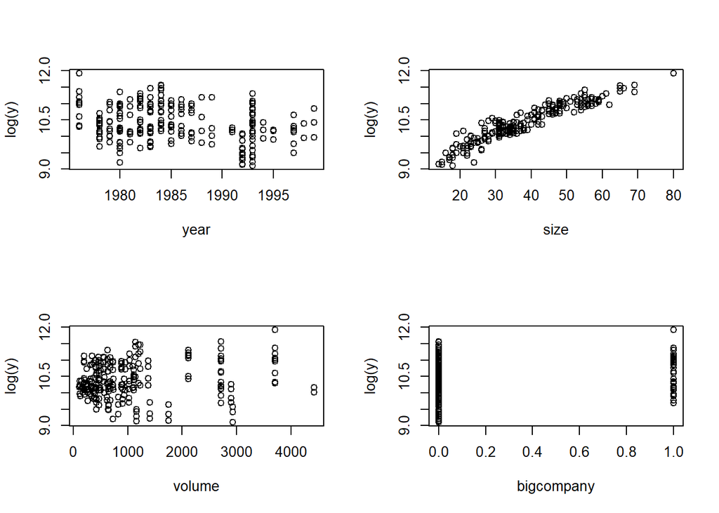

```r
#y transformation
plot(year, log(y))
plot(size, log(y))
plot(volume, log(y))
plot(bigcompany, log(y))
```

```r
ld1<-lm(y~year+size+volume+bigcompany, data = apt)
s1<-step(ld1); summary(s1) #AIC=4214.8, R-squared:  0.8774
```

```
## Start:  AIC=4215.68
## y ~ year + size + volume + bigcompany
##
##              Df  Sum of Sq        RSS    AIC
## - bigcompany  1 6.1742e+07 1.3013e+10 4214.8
## - year        1 8.4786e+07 1.3036e+10 4215.2
## <none>                     1.2952e+10 4215.7
## - volume      1 7.2893e+08 1.3681e+10 4226.6
## - size        1 8.0504e+10 9.3456e+10 4680.1
##
## Step:  AIC=4214.8
## y ~ year + size + volume
##
##          Df  Sum of Sq        RSS    AIC
## <none>                 1.3013e+10 4214.8
## - year    1 1.2243e+08 1.3136e+10 4215.0
## - volume  1 8.3585e+08 1.3849e+10 4227.5
## - size    1 8.4216e+10 9.7230e+10 4687.4
```

```
##
## Call:
## lm(formula = y ~ year + size + volume, data = apt)
##
## Residuals:
##    Min     1Q Median     3Q    Max
## -15901  -5213   -241   3923  42725
##
## Coefficients:
##               Estimate Std. Error t value Pr(>|t|)
## (Intercept) -2.945e+05  1.848e+05  -1.594 0.112374
## year         1.371e+02  9.280e+01   1.477 0.140930
## size         1.539e+03  3.971e+01  38.748  < 2e-16 ***
## volume       2.095e+00  5.427e-01   3.860 0.000147 ***
## ---
## Signif. codes:  0 '***' 0.001 '**' 0.01 '*' 0.05 '.' 0.1 ' ' 1
##
## Residual standard error: 7489 on 232 degrees of freedom
## Multiple R-squared:  0.8774, Adjusted R-squared:  0.8758
## F-statistic: 553.2 on 3 and 232 DF,  p-value: < 2.2e-16
```

```r
ld2<-lm(log(y)~year+size+volume+bigcompany, data = apt)
s2<-step(ld2); summary(s2) #AIC=-802.75, R-squared:  0.8906
```

```
## Start:  AIC=-801.51
## log(y) ~ year + size + volume + bigcompany
##
##              Df Sum of Sq    RSS     AIC
## - volume      1     0.024  7.602 -802.75
## <none>                     7.578 -801.51
## - year        1     0.099  7.677 -800.45
## - bigcompany  1     0.124  7.702 -799.67
## - size        1    53.416 60.994 -311.32
##
## Step:  AIC=-802.75
## log(y) ~ year + size + bigcompany
##
##              Df Sum of Sq    RSS     AIC
## <none>                     7.602 -802.75
## - year        1     0.075  7.678 -802.42
## - bigcompany  1     0.108  7.711 -801.41
## - size        1    53.398 61.000 -313.30
```

```
##
## Call:
## lm(formula = log(y) ~ year + size + bigcompany, data = apt)
##
## Residuals:
##      Min       1Q   Median       3Q      Max
## -0.65665 -0.11354 -0.02031  0.11660  0.47496
##
## Coefficients:
##               Estimate Std. Error t value Pr(>|t|)
## (Intercept) 15.2096948  4.1646024   3.652 0.000321 ***
## year        -0.0031760  0.0020928  -1.518 0.130490
## size         0.0394068  0.0009762  40.368  < 2e-16 ***
## bigcompany   0.0610813  0.0335679   1.820 0.070104 .
## ---
## Signif. codes:  0 '***' 0.001 '**' 0.01 '*' 0.05 '.' 0.1 ' ' 1
##
## Residual standard error: 0.181 on 232 degrees of freedom
## Multiple R-squared:  0.8906, Adjusted R-squared:  0.8892
## F-statistic: 629.6 on 3 and 232 DF,  p-value: < 2.2e-16
```

```r
ld3<-lm(y~(year+size+volume+bigcompany)^2, data = apt)
s3<-step(ld3); summary(s3) #AIC=4164.96, R-squared:  0.9048
```

```
## Start:  AIC=4167.75
## y ~ (year + size + volume + bigcompany)^2
##
##                     Df  Sum of Sq        RSS    AIC
## - year:bigcompany    1    4717780 1.0052e+10 4165.9
## - volume:bigcompany  1   40322512 1.0088e+10 4166.7
## <none>                            1.0047e+10 4167.7
## - size:bigcompany    1  121488837 1.0169e+10 4168.6
## - year:size          1  236372348 1.0284e+10 4171.2
## - year:volume        1  709454017 1.0757e+10 4181.9
## - size:volume        1 1917434008 1.1965e+10 4207.0
##
## Step:  AIC=4165.86
## y ~ year + size + volume + bigcompany + year:size + year:volume +
##     size:volume + size:bigcompany + volume:bigcompany
##
##                     Df  Sum of Sq        RSS    AIC
## - volume:bigcompany  1   46902473 1.0099e+10 4165.0
## <none>                            1.0052e+10 4165.9
## - size:bigcompany    1  121576279 1.0174e+10 4166.7
## - year:size          1  243197084 1.0295e+10 4169.5
## - year:volume        1  706126526 1.0758e+10 4179.9
## - size:volume        1 2070089973 1.2122e+10 4208.1
##
## Step:  AIC=4164.96
## y ~ year + size + volume + bigcompany + year:size + year:volume +
##     size:volume + size:bigcompany
##
##                   Df  Sum of Sq        RSS    AIC
## <none>                          1.0099e+10 4165.0
## - size:bigcompany  1  154351950 1.0253e+10 4166.5
## - year:size        1  207740907 1.0307e+10 4167.8
## - year:volume      1  690931651 1.0790e+10 4178.6
## - size:volume      1 2093589901 1.2192e+10 4207.4
```

```
##
## Call:
## lm(formula = y ~ year + size + volume + bigcompany + year:size +
##     year:volume + size:volume + size:bigcompany, data = apt)
##
## Residuals:
##      Min       1Q   Median       3Q      Max
## -13760.9  -4106.2   -774.1   3780.8  26841.4
##
## Coefficients:
##                   Estimate Std. Error t value Pr(>|t|)
## (Intercept)      1.474e+06  6.077e+05   2.426 0.016039 *
## year            -7.471e+02  3.057e+02  -2.444 0.015307 *
## size            -3.340e+04  1.601e+04  -2.086 0.038055 *
## volume          -8.335e+02  2.098e+02  -3.972 9.57e-05 ***
## bigcompany      -4.823e+03  4.365e+03  -1.105 0.270332
## year:size        1.740e+01  8.053e+00   2.161 0.031748 *
## year:volume      4.160e-01  1.056e-01   3.941 0.000108 ***
## size:volume      2.940e-01  4.286e-02   6.860 6.47e-11 ***
## size:bigcompany  1.864e+02  1.001e+02   1.863 0.063802 .
## ---
## Signif. codes:  0 '***' 0.001 '**' 0.01 '*' 0.05 '.' 0.1 ' ' 1
##
## Residual standard error: 6670 on 227 degrees of freedom
## Multiple R-squared:  0.9048, Adjusted R-squared:  0.9015
## F-statistic: 269.8 on 8 and 227 DF,  p-value: < 2.2e-16
```

```r
ld4<-lm(log(y)~(year+size+volume+bigcompany)^2, data = apt)
s4<-step(ld4); summary(s4) #AIC=-829.92, R-squared:  0.905
```

```
## Start:  AIC=-824.53
## log(y) ~ (year + size + volume + bigcompany)^2
##
##                     Df Sum of Sq    RSS     AIC
## - volume:bigcompany  1   0.00004 6.5328 -826.53
## - year:bigcompany    1   0.00090 6.5336 -826.50
## - size:bigcompany    1   0.03947 6.5722 -825.11
## <none>                           6.5327 -824.53
## - year:volume        1   0.05923 6.5920 -824.40
## - size:volume        1   0.22473 6.7575 -818.55
## - year:size          1   0.62357 7.1563 -805.02
##
## Step:  AIC=-826.53
## log(y) ~ year + size + volume + bigcompany + year:size + year:volume +
##     year:bigcompany + size:volume + size:bigcompany
##
##                   Df Sum of Sq    RSS     AIC
## - year:bigcompany  1   0.00129 6.5341 -828.49
## - size:bigcompany  1   0.04091 6.5737 -827.06
## <none>                         6.5328 -826.53
## - year:volume      1   0.06823 6.6010 -826.08
## - size:volume      1   0.23407 6.7668 -820.22
## - year:size        1   0.62915 7.1619 -806.83
##
## Step:  AIC=-828.49
## log(y) ~ year + size + volume + bigcompany + year:size + year:volume +
##     size:volume + size:bigcompany
##
##                   Df Sum of Sq    RSS     AIC
## - size:bigcompany  1   0.05502 6.5891 -828.51
## <none>                         6.5341 -828.49
## - year:volume      1   0.06921 6.6033 -828.00
## - size:volume      1   0.24371 6.7778 -821.84
## - year:size        1   0.67388 7.2079 -807.32
##
## Step:  AIC=-828.51
## log(y) ~ year + size + volume + bigcompany + year:size + year:volume +
##     size:volume
##
##               Df Sum of Sq    RSS     AIC
## - bigcompany   1   0.01646 6.6055 -829.92
## <none>                     6.5891 -828.51
## - year:volume  1   0.07335 6.6624 -827.89
## - size:volume  1   0.20517 6.7943 -823.27
## - year:size    1   0.70344 7.2925 -806.57
##
## Step:  AIC=-829.92
## log(y) ~ year + size + volume + year:size + year:volume + size:volume
##
##               Df Sum of Sq    RSS     AIC
## <none>                     6.6055 -829.92
## - year:volume  1   0.13208 6.7376 -827.25
## - size:volume  1   0.19686 6.8024 -824.99
## - year:size    1   0.69323 7.2988 -808.37
```

```
##
## Call:
## lm(formula = log(y) ~ year + size + volume + year:size + year:volume +
##     size:volume, data = apt)
##
## Residuals:
##      Min       1Q   Median       3Q      Max
## -0.72155 -0.11269 -0.01786  0.11273  0.43393
##
## Coefficients:
##               Estimate Std. Error t value Pr(>|t|)
## (Intercept)  6.991e+01  1.502e+01   4.654 5.52e-06 ***
## year        -3.066e-02  7.558e-03  -4.057 6.81e-05 ***
## size        -1.951e+00  4.059e-01  -4.806 2.78e-06 ***
## volume       1.015e-02  4.804e-03   2.113  0.03564 *
## year:size    1.001e-03  2.042e-04   4.902 1.79e-06 ***
## year:volume -5.170e-06  2.416e-06  -2.140  0.03342 *
## size:volume  2.770e-06  1.061e-06   2.612  0.00959 **
## ---
## Signif. codes:  0 '***' 0.001 '**' 0.01 '*' 0.05 '.' 0.1 ' ' 1
##
## Residual standard error: 0.1698 on 229 degrees of freedom
## Multiple R-squared:  0.905,  Adjusted R-squared:  0.9025
## F-statistic: 363.4 on 6 and 229 DF,  p-value: < 2.2e-16
```

```r
data.frame('R-squared' = c(summary(s1)$r.squared,summary(s2)$r.squared,
                         summary(s3)$r.squared,summary(s4)$r.squared),
           'p' = c(extractAIC(s1)[1],extractAIC(s2)[1],extractAIC(s3)[1],extractAIC(s4)[1]),
          'AIC' = c(extractAIC(s1)[2],extractAIC(s2)[2],extractAIC(s3)[2],extractAIC(s4)[2]),
           row.names = c('y','logy','y_^2','logy_^2'))
```

```
##         R.squared p       AIC
## y       0.8773578 4 4214.7986
## logy    0.8906091 4 -802.7495
## y_^2    0.9048259 9 4164.9576
## logy_^2 0.9049519 7 -829.9181
```

##### R-squared

- p가 커지면, R^2는 반드시 커짐.
- 1번 모델 -> 2번 모델 p의 개수 동일함에도 R-squared증가
- 3번 모델 -> 4번 모델 p감소 하였음에도 R-suqred증가가

log(y) transformation이 좋은 결과를 낳음.

##### AIC

- 1번,3번 모델끼리, 2번,4번 모델끼리 비교만 가능.
- AIC가 더 작은 3번, 4번이 더 좋음.

AIC, R^2 외에도 Cp, MSE 등 좋은 모델을 선택하는 데에는 여러가지 기준이 있음.